# Plot BEAST MCC Trees with traits in R

Samantha Lycett

2024-02-21

# Plotting BEAST MCC Trees in R

## Load required R packages

Trees in general can be used and manipulated within R using R package ape. To plot on maps, then the base R maps packages can be used.

```r
# uncomment to install if required
#install.packages("ape")
#install.packages("maps")
#install.packages("mapdata")
#install.packages("mapproj")
#install.packages("conicfit")

# now load required packages

# base trees
library(ape)

# maps
library(maps)
library(mapdata)
library(mapproj)

# needed to fit HPDs to ellipses
library(conicfit)
```

## Load custom R functions

BEAST MCC trees are in extended nexus format, but they can be read into R using a variety of custom functions, including ggtree.

However, here we will use my own custom code Lycett_phylo [hasnt quite made it into a public R package yet]

```r
# load Lycett_phylo utility code as separate functions
source("getEl.R")
source("calcDecimalDate.R")
source("read_MCC_tree.R")
source("get_BEAST_cols.R")
source("custom_map_movie.R")
```

## Read in MCC Tree

Set the tree file name in the code. This example is an MCC tree containing 2 discrete traits and latitude-longitude coordinates as continuous (spatial) traits.

```r
# define tree file name
treeName <- "cov_net_sim_mper2_120genomes_TN93G4_strict_skygrid_traits_2_mcc.tre"
```

Use the custom functions to read in the mcc tree and add the traits and highest posterior density interval information.

```r
# read in tree using custom function (could use ggtree also)
tr <- read_latlon_mcc_tr(treeName)

# need to add the decimal dates [not always necessary but need to do this in this example]
tr$decDates    <- apply(as.matrix(apply(as.matrix(tr$tip.label), 1, getEl, ind=1, sep="\\|", fromEnd=TRUE)), 1,calcDecimalDate_from_yymmdd,sep="-")
tr$youngestTip <- max(tr$decDates)
tr <- nodeTimes(tr, youngestTip=tr$youngestTip)

# now add the discrete traits to the tr object
tr <- addDiscreteTraits(tr)

# now add the highest posterior density intervals
tr <- addLatLonHPD(tr)
tr <- fit_HPDs_to_standard(tr,ltol=0.005)
tr$ntips <- length(tr$tip.label)
```

#### Brief Examination of the tree object

The base tree object is:

```r
print(tr)
```

```
##
## Phylogenetic tree with 120 tips and 119 internal nodes.
##
## Tip labels:
##   England/SHE0109-567|Sheffield|2022-02-05, England/SHE0120-726|Sheffield|2022-02-08, England/SHE0123-1224|Sheffield|2022-02-15, England/SHE0117-1056|Sheffield|2022-02-13, England/SHE0104-2874|Sheffield|2022-04-21, England/SHE0121-2010|Sheffield|2022-02-28, ...
##
## Rooted; includes branch lengths.
```

This tree object also as the traits attached to it:

```r
attributes(tr)
```

```
## $names
##  [1] "edge"         "edge.length"  "Nnode"        "tip.label"    "tip.details"
##  [6] "node.details" "details"      "nodeDists"    "rootHeight"   "nodeTimes"
## [11] "latlon"       "decDates"     "youngestTip"  "props"        "uprops"
## [16] "propNames"    "propProb"     "lat80"        "lon80"        "hpds"
## [21] "hpd_diffs"    "ntips"
##
## $class
## [1] "phylo"
##
## $order
## [1] "cladewise"
```

The discrete traits that have been read in are:

```r
print(tr$propNames)
```

```
## [1] "Country" "Place"
```

When the tree is read in, the trait values are stored in the props (properties) array, and the order is by sequence (numbers 1 to number of tips, i.e. 1:ntips), followed by the internal nodes of the tree starting with the root.

The distribution of discrete traits in the sequence data set (tips) for discrete trait 1, which is Country is:

```r
propIndex <- 1
kable(t(table(tr$props[1:tr$ntips,propIndex])),
      caption=paste("Number of sequences per",tr$propNames[propIndex]))
```

Number of sequences per Country

| France | Norway | UK |
| --- | --- | --- |
| 12 | 14 | 94 |

The distribution of discrete traits in the sequence data set (tips) for discrete trait 2, which is Place is:

```r
propIndex <- 2
kable(t(table(tr$props[1:tr$ntips,propIndex])),
      caption=paste("Number of sequences per",tr$propNames[propIndex]))
```

Number of sequences per Place

| Aberdeen | Birmingham | Cambridge | Cardiff | Edinburgh | Glasgow | London | Oslo | Paris | Sheffield |
| --- | --- | --- | --- | --- | --- | --- | --- | --- | --- |
| 9 | 10 | 12 | 15 | 13 | 12 | 11 | 14 | 12 | 12 |

A spatial diffusion model with latitude and longitude was also included in this BEAST run, so the MCC tree contains latitude and longitude. Here this has been attached to the tree object in attribute tr$latlon, and the range of values (including the internal nodes of the tree) are:

```r
lltbl <- c(min(tr$latlon[,1]),max(tr$latlon[,1]),min(tr$latlon[,2]),max(tr$latlon[,2]))
names(lltbl) <- c("Min Lat","Max Lat","Min Lon","Max Lon")
kable(t(lltbl),caption="Range of Lat-Lon values")
```

Range of Lat-Lon values

| Min Lat | Max Lat | Min Lon | Max Lon |
| --- | --- | --- | --- |
| 48.2981 | 62.31153 | -6.6 | 10.36881 |

The latitude-longitude spatial coordinates of the sequences and internal nodes can be plain plotted to check

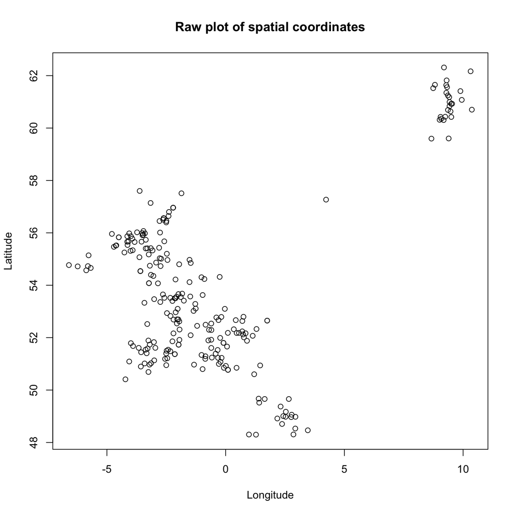

```r
plot(tr$latlon[,2], tr$latlon[,1], xlab="Longitude", ylab="Latitude")
title("Raw plot of spatial coordinates")
```

## Plotting the tree

We will first reorder the branches of the tree, and then plot using base R package ape

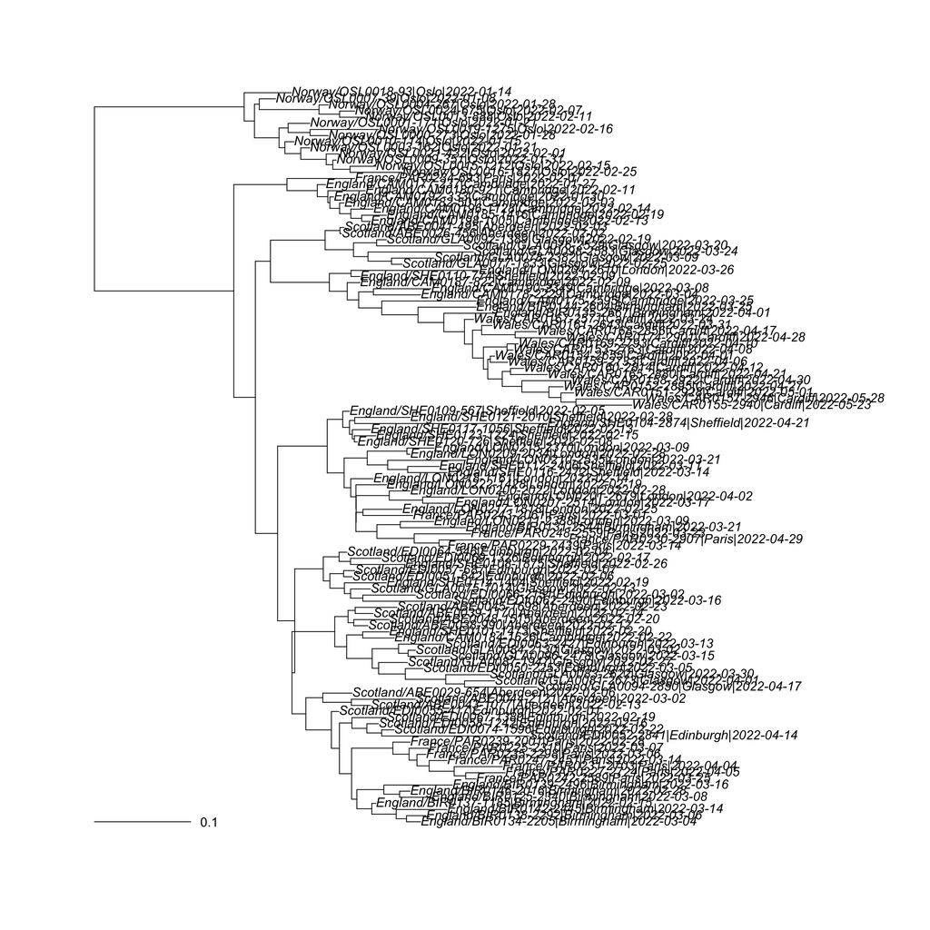

```r
tr <- ladderize(tr)
plot(tr)
add.scale.bar()
```

Now use the custom functions to plot the tree with discrete traits, and omit the sequence names from the plot. Since there are two discrete traits in this example we will plot both.

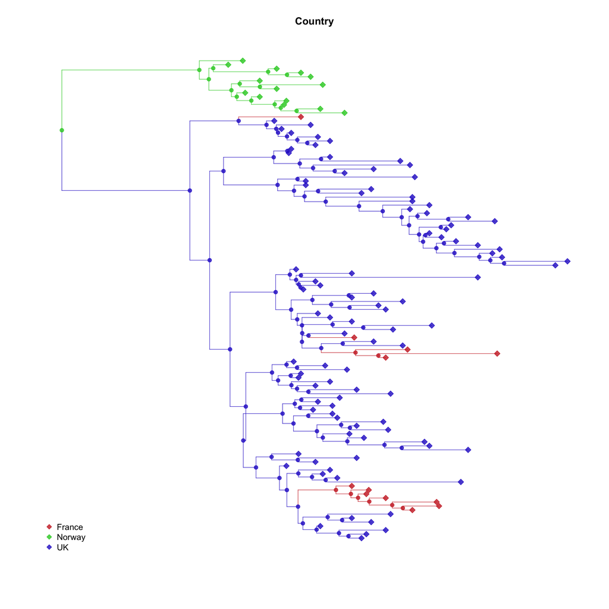

```r
propIndex <- 1
plot_discrete_tree(tr, propIndex=propIndex, show.tip.label=FALSE)
```

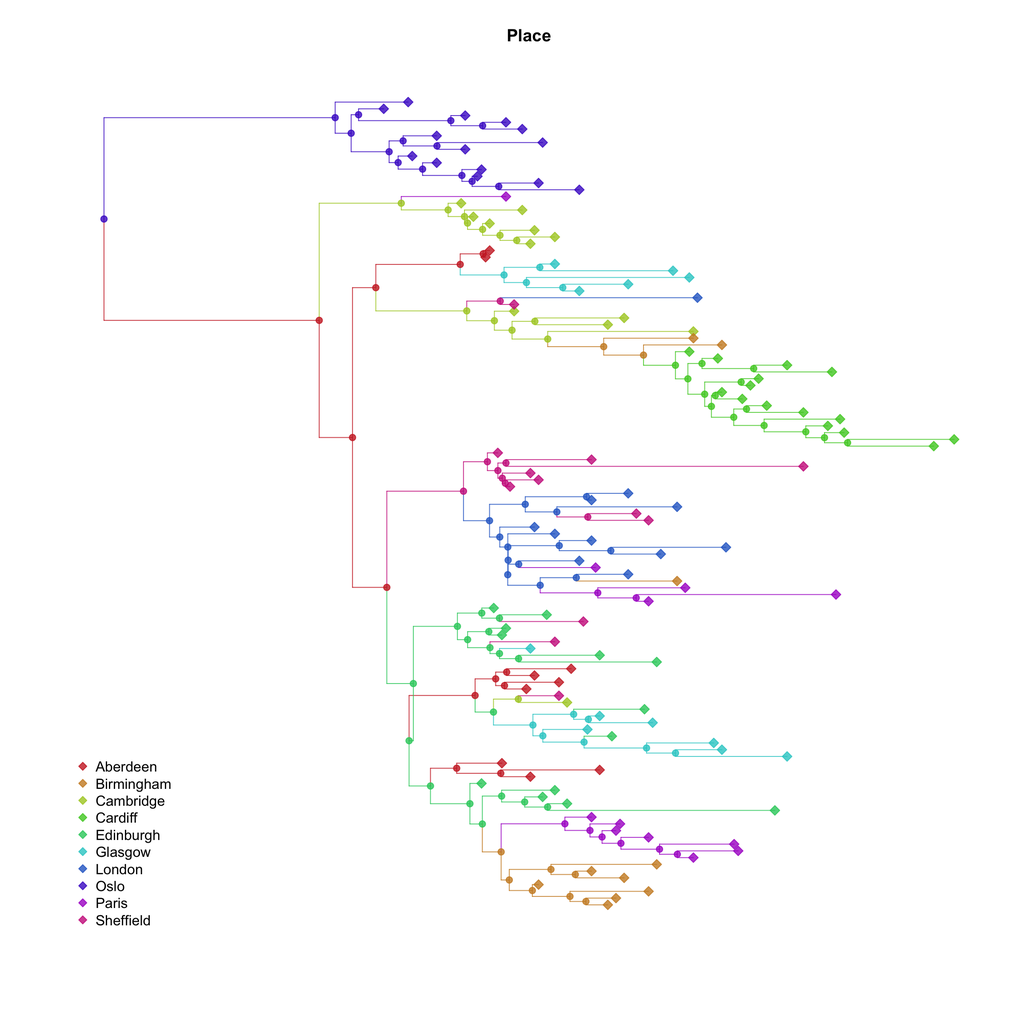

```r
propIndex <- 2
plot_discrete_tree(tr, propIndex=propIndex, show.tip.label=FALSE)
```

## Plotting tree on a map

A spatial diffusion model with latitude and longitude was also included in this BEAST run, so the MCC tree contains latitude and longitude information and associated spatial HPD intervals.

Using custom code plot_mcc_tree_with_hpds, colour by the first discrete trait, which here is Country:

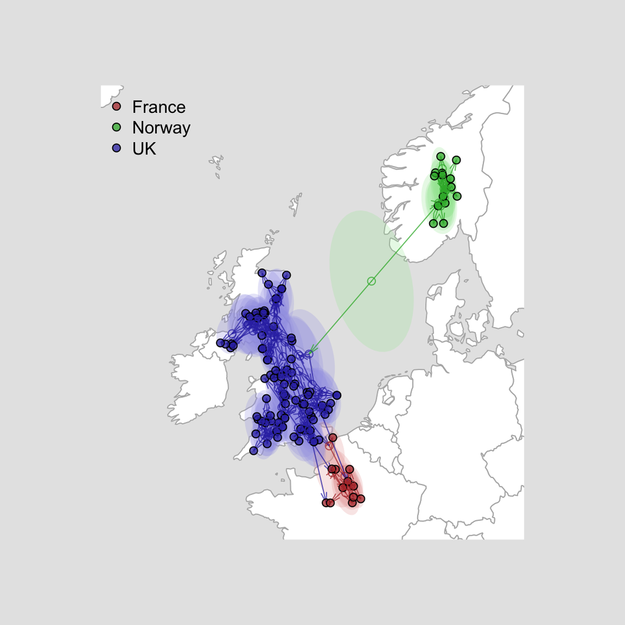

```r
# plot tree on map
plot_mcc_tree_with_hpds(tr, propIndex=1, xlim=c(-15,15), ylim=c(47,65), legpos="topleft")
```

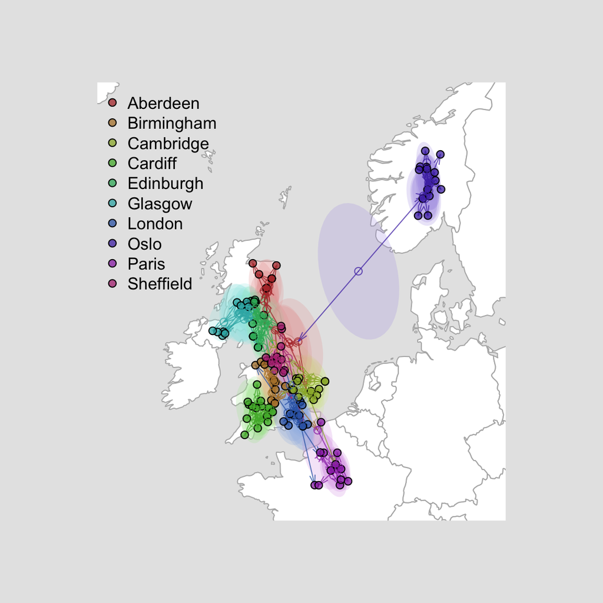

```r
# plot tree on map
plot_mcc_tree_with_hpds(tr, propIndex=2, xlim=c(-15,15), ylim=c(47,65), legpos="topleft")
```